# Visualization of Genotyping Results

Dataset: big - 24 barcodes

31 October 2026

This script uses a lot of different chunks to visualize different genotyping results from different methods. Its really kinda long, before every chunk is a quick description of what im trying to show with the plots and some ideas and questions I was trying to answer with the visualization. Plots are saved inside Results/dataset_name/Graphics/…

After completing this script, move on to 07_Failed_Genotypes_Analysis.Rmd

## 1 Settings, paths and basic setup

This chunks contain libraries, global settings, editable variables used by the whole .Rmd and paths for necessary input files.

```r
suppressMessages({
  library(grid)
  library(Biostrings) # loaded firts because of shared functions names with dplyr
  library(pwalign)
  library(ggplot2)
  library(lme4)
  library(dplyr)
  library(tidyr)
  library(readr)
  library(readxl)
  library(patchwork)
  library(scales)
  library(parallel)
  library(knitr)
})

# Settings come from the params block in the YAML header, this turns them into usable variables
invisible(list2env(params, envir = environment()))
settings_used <- data.frame(setting = c("run_date", names(params)),
                            value = c(format(Sys.time(), "%Y-%m-%d %H:%M"),
                                      vapply(params, function(setting_value) paste(setting_value, collapse = ", "), character(1))))
# Uploading shared functions
source("Code/R_scripts/asp_functions.R", local = TRUE)

plot_font <- "Times New Roman"
theme_set(theme_minimal(base_family = plot_font))
hm_dark <- "#476F84"
hm_light <- "#A4BED5" #HM
ht_dark <- "#A4552A"
ht_light <- "#DDA77B" # HT
correct_colour <- "#72874E" # correct calls, reads used
error_colour <- "#d73027" # miscalls, incorrect calls, removing cutoffs
no_call_colour <- "grey70"
no_reference_colour <- "grey97"
fwd_colour <- "#B35806"
rv_colour <- "#542788" # forward and reverse reads
method_colours <- c(ASP = "#834D24", ASP_bayesian = "#834D24", minimap2 = "#E1C473")

# Paths for genotype and graphics outputs
graphics_dir <- file.path("Results", dataset_name, "Graphics")
genotypes_dir <- file.path("Results", dataset_name, "Genotypes_results")

# Shared function for building accurate settings based folder names
run_names <- build_run_names(input_type, use_anchors, anchor_length, threshold_type, error_rate, min_score_fraction,
                             prior_type, prior_het_share, prior_population, prior_floor, probe_type = probe_type,
                             ancestry_prior_shape = ancestry_prior_shape, phi_hom_structure = phi_hom_structure)
asp_run_name <- run_names$asp_run_name
prior_label <- run_names$prior_label
bayes_run_name <- run_names$bayes_run_name

asp_path <- file.path(genotypes_dir, asp_run_name, "all_barcodes_asp_genotypes.tsv") # ASP Genotyper results and per read calls
asp_reads_path <- file.path(genotypes_dir, asp_run_name, "all_barcodes_asp_reads.tsv")
mm2_path <- file.path(genotypes_dir, "MiniMap2_genotypes/all_barcodes_Minimap2_genotypes.tsv") # MiniMap2 genotype results
bayes_path <- file.path(genotypes_dir, bayes_run_name, "all_barcodes_base_mixture_genotypes_hierarchical.tsv") # ASP Hierarchical Bayes Genotyper results
ref_path <- file.path("Data/Supporting_data/Reference_genotypes", paste0("genotypes_", dataset_name, ".tsv")) # Genotype references

# Primer panel preparation with a shared function and the same scoring lookups for scoring threshold, problematic locus and Sankey plots
panel <- prepare_primer_panel(primer_panel_path, reference_path, input_type, use_anchors, anchor_length, probe_type = probe_type)
match_lookup <- build_match_lookup(primer_quality)
mismatch_cost_lookup <- vapply(0:93, function(q) mismatch_cost_f(q, primer_quality), numeric(1))

# Output paths for Identified, Bayes and MiniMap2 plots
out_dir <- file.path(graphics_dir, "ASP_Genotypes_Results_Plots")
dir.create(out_dir, recursive = TRUE, showWarnings = FALSE)
bayes_run_graphics_dir <- file.path(graphics_dir, "STAN_Hierarchical", run_names$bayes_settings_label)
bayes_out_dir <- file.path(bayes_run_graphics_dir, "Basic_Results_Plots")
dir.create(bayes_out_dir, recursive = TRUE, showWarnings = FALSE)
mm2_out_dir <- file.path(graphics_dir, "Minimap2_Genotypes_Results_Plots")
dir.create(mm2_out_dir, recursive = TRUE, showWarnings = FALSE)

# Imported shared data between all chunks, loaded and cleaned once in setup
asp_results <- read_tsv(asp_path, show_col_types = FALSE)
asp <- asp_results %>%
  transmute(sample = barcode, locus, genotype, method = "ASP")

bayes_raw <- read_tsv(bayes_path, show_col_types = FALSE)
bayes_asp <- bayes_raw %>%
  transmute(sample = barcode, locus, genotype, method = "ASP_bayesian", status)

mm2_raw <- read_tsv(mm2_path, show_col_types = FALSE)
mm2 <- mm2_raw %>%
  transmute(sample = barcode, locus, genotype, method = "minimap2")

ref <- read_tsv(ref_path, show_col_types = FALSE) %>%
  transmute(sample = sample_id, locus, genotype, method = "reference")
```

## 2 Basic visualization for ASP genotypes results

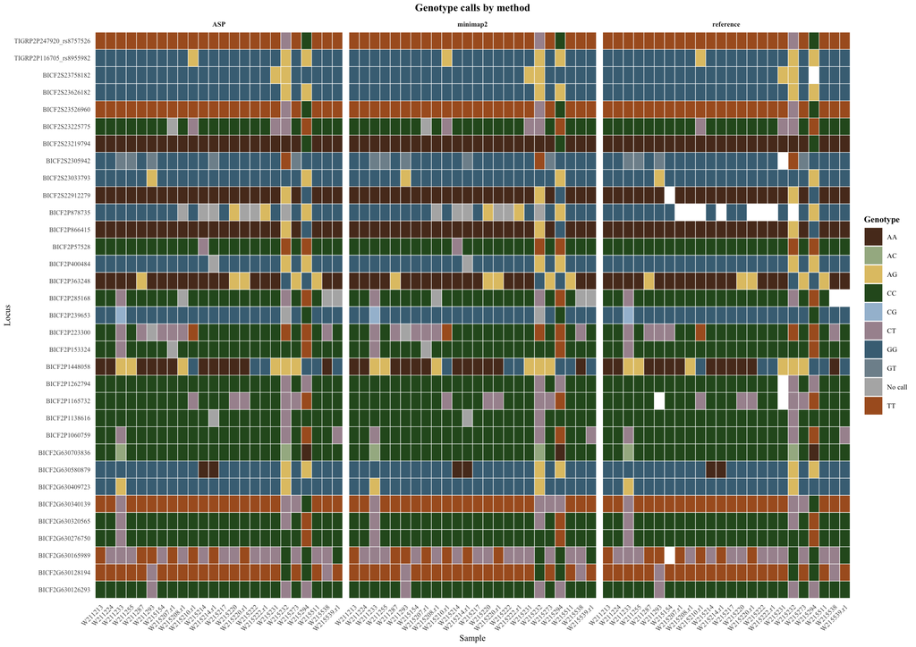

```r
# Full data frame with all the genotypes
all_calls <- bind_rows(asp, mm2, ref)

# Comparison table sample and locus pairs per row and a match column per method
wide <- all_calls %>%
  pivot_wider(names_from = method, values_from = genotype) %>%
  complete(sample, locus) %>%
  mutate(asp_match = ASP == reference, # T or F, NA if one is missing
         mm2_match = minimap2 == reference,
         methods_agree = ASP == minimap2)

write.table(wide, file.path(out_dir, "full_comparison_table_identified.tsv"), sep = "\t", row.names = FALSE, quote = FALSE)

# 1. Plot: Creates called genotypes heatmap per method
genotype_colours <- c(
  "AA" = "#593722",
  "CC" = "#2C5724",
  "GG" = "#476F84",
  "TT" = "#AB5D26",
  "AC" = "#A4B591",
  "AG" = "#E1C473",
  "AT" = "#D9A877",
  "CG" = "#A4BED5",
  "CT" = "#A8939E",
  "GT" = "#7F919B",
  "No call" = no_call_colour)

plot_data <- all_calls %>%
  mutate(genotype_display = ifelse(is.na(genotype), "No call", genotype))

p1 <- ggplot(plot_data, aes(x = sample, y = locus, fill = genotype_display)) +
  geom_tile(colour = "white", linewidth = 0.2) +
  facet_wrap(~method, ncol = 3) + # Splits into 3 panels
  scale_fill_manual(values = genotype_colours, name = "Genotype") +
  labs(title = "Genotype calls by method", x = "Sample", y = "Locus") +
  theme_minimal(base_family = plot_font, base_size = 8) +
  theme(plot.title = element_text(face = "bold", hjust = 0.5),
        legend.title = element_text(face = "bold"),
        strip.text = element_text(face = "bold"),
        axis.text.x = element_text(angle = 45, hjust = 1),
        axis.text.y = element_text(size = 6),
        panel.grid = element_blank())

ggsave(file.path(out_dir, "genotype_heatmap_by_method.png"), p1,
       width = 14, height = max(6, length(unique(plot_data$locus)) * 0.15 + 2), dpi = 300, limitsize = FALSE, bg = "white")
ggsave(file.path(out_dir, "genotype_heatmap_by_method.pdf"), p1,
       width = 14, height = max(6, length(unique(plot_data$locus)) * 0.15 + 2), limitsize = FALSE, device = cairo_pdf)
print(p1)
```

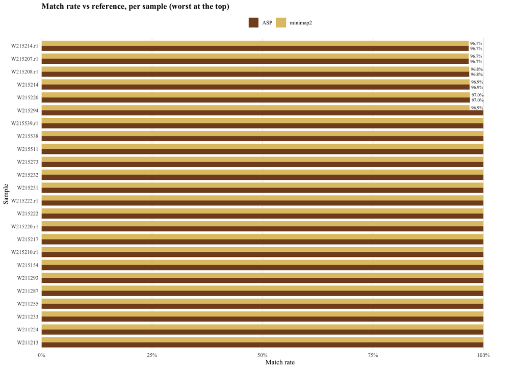

```r
# 2. Plot: Genotype match rate per sample
per_sample <- wide %>%
  filter(!is.na(reference)) %>%
  group_by(sample) %>%
  summarise(
    ASP = mean(asp_match, na.rm = TRUE),
    minimap2 = mean(mm2_match, na.rm = TRUE)) %>%
  pivot_longer(cols = c(ASP, minimap2), names_to = "method", values_to = "match_rate")

p2 <- ggplot(per_sample, aes(x = match_rate, y = reorder(sample, -match_rate), fill = method)) +
  geom_col(position = position_dodge(width = 0.8), width = 0.8) +
  geom_text(aes(label = ifelse(match_rate < 1, percent(match_rate, accuracy = 0.1), "")),
            position = position_dodge(width = 0.8), hjust = -0.15, size = 2.6) +
  scale_fill_manual(values = method_colours, name = NULL) +
  scale_x_continuous(labels = percent, expand = expansion(mult = c(0, 0.08))) +
  labs(title = "Match rate vs reference, per sample (worst at the top)", x = "Match rate", y = "Sample") +
  theme_minimal(base_family = plot_font, base_size = 11) +
  theme(plot.title = element_text(face = "bold"), legend.position = "top",
        panel.grid.major.y = element_blank(), panel.grid.minor = element_blank())

ggsave(file.path(out_dir, "concordance_per_sample.png"), p2, width = 8.27, height = 11.69, dpi = 300, bg = "white")
ggsave(file.path(out_dir, "concordance_per_sample.pdf"), p2, width = 8.27, height = 11.69, device = cairo_pdf)
print(p2)
```

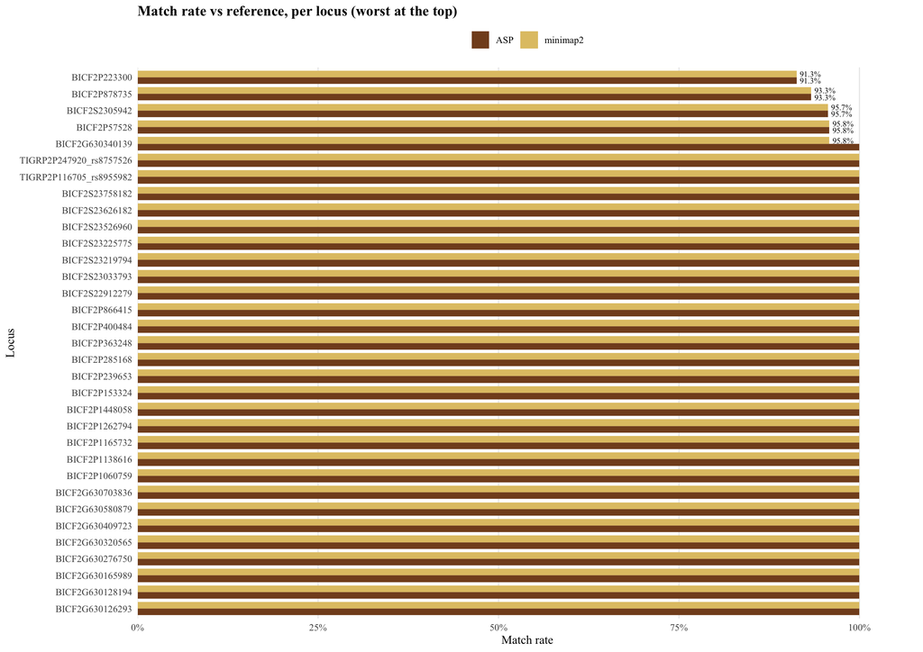

```r
# 3. Plot: Result concordance per locus
per_locus <- wide %>%
  filter(!is.na(reference)) %>%
  group_by(locus) %>%
  summarise(
    ASP = mean(asp_match, na.rm = TRUE),
    minimap2 = mean(mm2_match, na.rm = TRUE)) %>%
  pivot_longer(cols = c(ASP, minimap2), names_to = "method", values_to = "match_rate")

# Average for both method, worst first
locus_avg <- per_locus %>%
  group_by(locus) %>%
  summarise(avg_match = mean(match_rate, na.rm = TRUE)) %>%
  arrange(avg_match)

p3 <- ggplot(per_locus, aes(x = match_rate, y = reorder(locus, -match_rate), fill = method)) +
  geom_col(position = position_dodge(width = 0.8), width = 0.8) +
  geom_text(aes(label = ifelse(match_rate < 1, percent(match_rate, accuracy = 0.1), "")),
            position = position_dodge(width = 0.8), hjust = -0.15, size = 2.6) +
  scale_fill_manual(values = method_colours, name = NULL) +
  scale_x_continuous(labels = percent, expand = expansion(mult = c(0, 0.08))) +
  labs(title = "Match rate vs reference, per locus (worst at the top)", x = "Match rate", y = "Locus") +
  theme_minimal(base_family = plot_font, base_size = 11) +
  theme(plot.title = element_text(face = "bold"), legend.position = "top",
        panel.grid.major.y = element_blank(), panel.grid.minor = element_blank())

ggsave(file.path(out_dir, "concordance_per_locus.png"), p3, width = 8.27, height = 11.69, dpi = 300, bg = "white")
ggsave(file.path(out_dir, "concordance_per_locus.pdf"), p3, width = 8.27, height = 11.69, device = cairo_pdf)
print(p3)
```

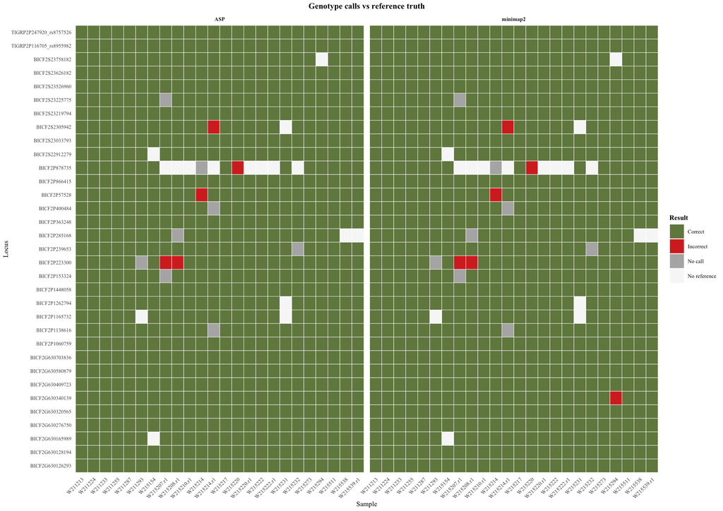

```r
# 4. Plot: Same as first heatmap just simpler with only red and green values for correct and incorrect called genotypes
match_data <- wide %>%
  select(sample, locus, reference, ASP = asp_match, minimap2 = mm2_match) %>%
  pivot_longer(cols = c(ASP, minimap2), names_to = "method", values_to = "is_match") %>%
  mutate(
    match_category = case_when(
      is.na(reference) ~ "No reference",
      is.na(is_match) ~ "No call",
      is_match ~ "Correct",
      TRUE ~ "Incorrect"))

p4 <- ggplot(match_data, aes(x = sample, y = locus, fill = match_category)) +
  geom_tile(colour = "white", linewidth = 0.2) +
  facet_wrap(~method, ncol = 2) +
  scale_fill_manual(
    values = c("Correct" = correct_colour, "Incorrect" = error_colour,
               "No call" = no_call_colour, "No reference" = no_reference_colour),
    name = "Result") +
  labs(title = "Genotype calls vs reference truth", x = "Sample", y = "Locus") +
  theme_minimal(base_family = plot_font, base_size = 8) +
  theme(plot.title = element_text(face = "bold", hjust = 0.5),
        legend.title = element_text(face = "bold"),
        strip.text = element_text(face = "bold"),
        axis.text.x = element_text(angle = 45, hjust = 1),
        axis.text.y = element_text(size = 6),
        panel.grid = element_blank())

ggsave(file.path(out_dir, "genotype_match_heatmap.png"), p4, width = max(9, length(unique(match_data$sample)) * 0.5 + 3),
       height = max(6, length(unique(match_data$locus)) * 0.15 + 2), dpi = 300, limitsize = FALSE, bg = "white")
ggsave(file.path(out_dir, "genotype_match_heatmap.pdf"), p4, width = max(9, length(unique(match_data$sample)) * 0.5 + 3),
       height = max(6, length(unique(match_data$locus)) * 0.15 + 2), limitsize = FALSE, device = cairo_pdf)
print(p4)
```

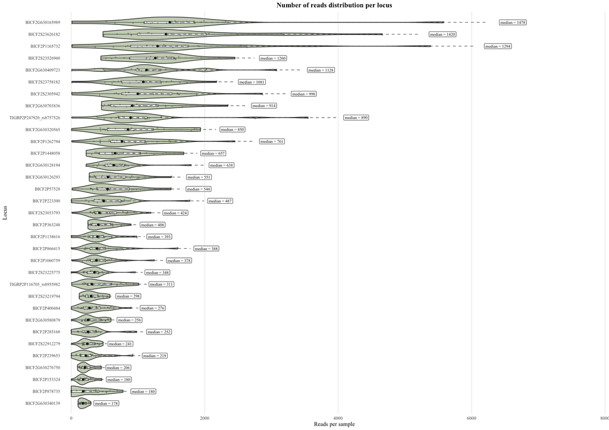

```r
# 5. Plot: Depth per locus and locus family in violin plots
depth_family_pattern <- "^(BICF2P|BICF2S|BICF2G|TIGRP2P)"

# Creates locus families from the names prefix
depth_data <- asp_results %>%
  transmute(sample = barcode, locus, depth,
            locus_group = ifelse(grepl(depth_family_pattern, locus), sub(paste0(depth_family_pattern, ".*"), "\\1", locus), "Other"))

depth_fills <- c("all" = "#A4B591", "BICF2P" = "#AB5D26", "BICF2S" = "#E1C473", "BICF2G" = "#55804D", "TIGRP2P" = "#593722", "Other" = "grey70")

# One violin plot per row
depth_violin_f <- function(data, title, x_label, y_label) {
  medians <- data %>%
    group_by(row) %>%
    summarise(median_depth = median(depth, na.rm = TRUE), max_depth = max(depth, na.rm = TRUE))

  ggplot(data, aes(x = depth, y = row)) +
    geom_violin(aes(fill = fill_group), colour = "grey20", linewidth = 0.4, alpha = 0.6, scale = "width") +
    geom_boxplot(width = 0.15, fill = "white", colour = "grey30", outlier.shape = NA, linewidth = 0.3) +
    geom_jitter(height = 0.12, width = 0, size = 0.5, alpha = 0.35, colour = "grey30") +
    geom_point(data = medians, aes(x = median_depth, y = row), colour = "grey10", size = 1.2, inherit.aes = FALSE) +
    geom_segment(data = medians, aes(x = median_depth, xend = max_depth * 1.12, y = row, yend = row),
                 linetype = "dashed", colour = "grey30", linewidth = 0.3, inherit.aes = FALSE) +
    geom_label(data = medians, aes(x = max_depth * 1.15, y = row, label = sprintf("median = %.0f", median_depth)),
               hjust = 0, size = 2, fill = "white", linewidth = 0.2, inherit.aes = FALSE) +
    scale_fill_manual(values = depth_fills, name = "Locus\ngroup",
                      guide = if (n_distinct(data$fill_group) > 1) "legend" else "none") + # legend only when coloured by family
    scale_x_continuous(expand = expansion(mult = c(0.02, 0.25))) +
    scale_y_discrete(expand = expansion(add = 0.9)) + # space between the rows
    theme_minimal(base_family = plot_font, base_size = 8) +
    theme(axis.text.y = element_text(size = 6),
          panel.grid.minor = element_blank(),
          panel.grid.major.y = element_blank(),
          plot.title = element_text(hjust = 0.5, face = "bold")) +
    labs(title = title, x = x_label, y = y_label)
}

# Depth per locus ordered by median depth, violin plots
depth_plot_locus <- depth_violin_f(depth_data %>% mutate(row = reorder(locus, depth, FUN = median, na.rm = TRUE), fill_group = "all"), "Number of reads distribution per locus", "Reads per sample", "Locus")
print(depth_plot_locus)
```

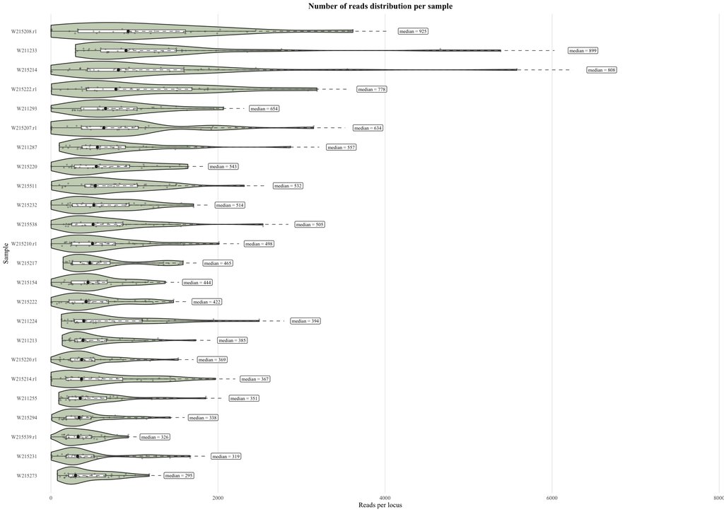

```r
ggsave(file.path(out_dir, "read_distribution_per_locus_violin.png"), depth_plot_locus, width = 8.27, height = 11.69, dpi = 300, bg = "white")
ggsave(file.path(out_dir, "read_distribution_per_locus_violin.pdf"), depth_plot_locus, width = 8.27, height = 11.69, device = cairo_pdf)

# 6. Plot: Depth per sample ordered by median depth, violin plots
depth_plot_sample <- depth_violin_f(depth_data %>% mutate(row = reorder(sample, depth, FUN = median, na.rm = TRUE), fill_group = "all"), "Number of reads distribution per sample", "Reads per locus", "Sample")
print(depth_plot_sample)
```

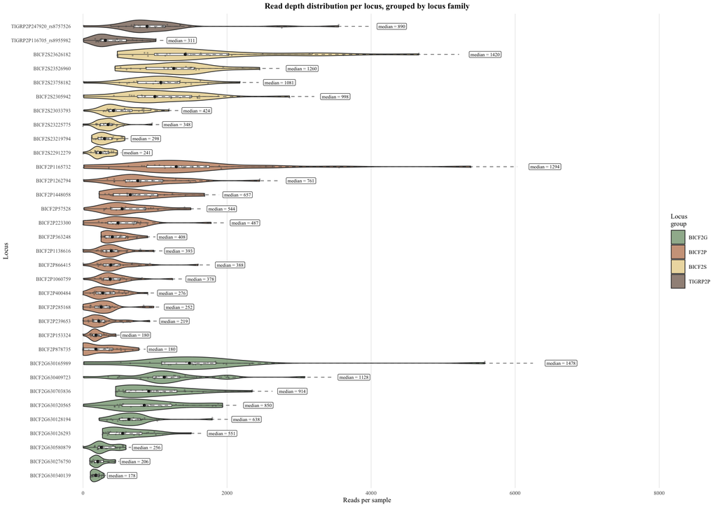

```r
ggsave(file.path(out_dir, "read_distribution_per_sample_violin.png"), depth_plot_sample, width = 8.27, height = 11.69, dpi = 300, bg = "white")
ggsave(file.path(out_dir, "read_distribution_per_sample_violin.pdf"), depth_plot_sample, width = 8.27, height = 11.69, device = cairo_pdf)

# 7. Plot: Depth per locus family ordered in groups by median depth, violin plots
depth_grouped_order <- depth_data %>%
  group_by(locus_group, locus) %>%
  summarise(median_depth = median(depth, na.rm = TRUE), .groups = "drop") %>%
  arrange(locus_group, median_depth) %>%
  pull(locus)

depth_plot_grouped <- depth_violin_f(depth_data %>% mutate(row = factor(locus, levels = depth_grouped_order), fill_group = locus_group), "Read depth distribution per locus, grouped by locus family", "Reads per sample", "Locus")
print(depth_plot_grouped)
```

```r
ggsave(file.path(out_dir, "read_depth_per_locus_grouped_violin.png"), depth_plot_grouped, width = 8.27, height = 11.69, dpi = 300, bg = "white")
ggsave(file.path(out_dir, "read_depth_per_locus_grouped_violin.pdf"), depth_plot_grouped, width = 8.27, height = 11.69, device = cairo_pdf)
```

## 3 Hierarchical bayes base mixture type

This chunk contains the same first version of visualizations created for hierarchical Bayes model, same plots as the previous chunk just changed input paths and output paths for Bayes.

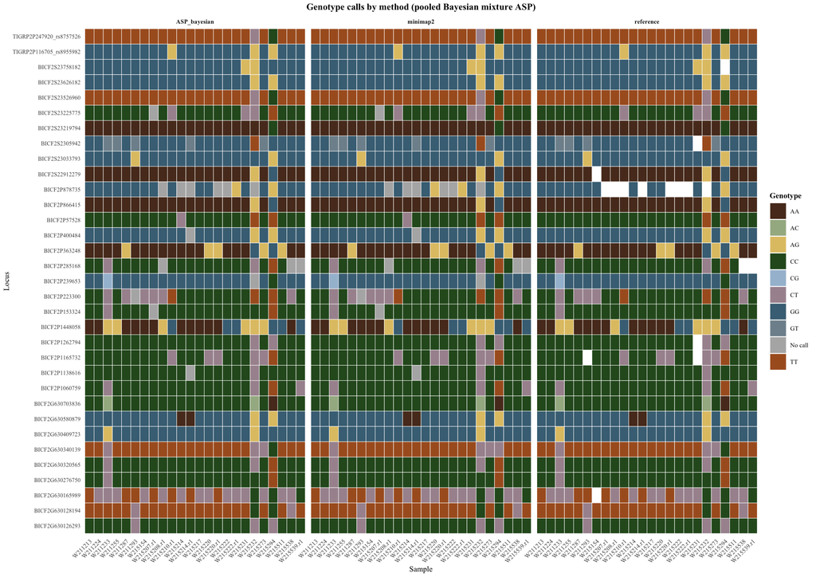

```r
# Same chunks before it just uses Bayesian Genotypes results tables imported and cleaned in the setup chunk
bayes_all_calls <- bind_rows(select(bayes_asp, -status), mm2, ref)

# Comparison table sample and locus pairs per row and a match column per method
bayes_wide <- bayes_all_calls %>%
  pivot_wider(names_from = method, values_from = genotype) %>%
  complete(sample, locus) %>%
  mutate(asp_match = ASP_bayesian == reference, # T or F, NA if one is missing
         mm2_match = minimap2 == reference)

write.table(bayes_wide, file.path(bayes_out_dir, "full_comparison_table_bayesian_mixpooled.tsv"), sep = "\t", row.names = FALSE, quote = FALSE)

# 1. Plot: Creates called genotypes heatmap per method
bayes_plot_data <- bayes_all_calls %>%
  mutate(genotype_display = ifelse(is.na(genotype), "No call", genotype))

p_bayes_genotypes <- ggplot(bayes_plot_data, aes(x = sample, y = locus, fill = genotype_display)) +
  geom_tile(colour = "white", linewidth = 0.2) +
  facet_wrap(~method, ncol = 3) +
  scale_fill_manual(values = genotype_colours, name = "Genotype") +
  labs(title = "Genotype calls by method (pooled Bayesian mixture ASP)", x = "Sample", y = "Locus") +
  theme_minimal(base_family = plot_font, base_size = 8) +
  theme(plot.title = element_text(face = "bold", hjust = 0.5),
        legend.title = element_text(face = "bold"),
        strip.text = element_text(face = "bold"),
        axis.text.x = element_text(angle = 45, hjust = 1),
        axis.text.y = element_text(size = 6),
        panel.grid = element_blank())

ggsave(file.path(bayes_out_dir, "genotype_heatmap_by_method_bayesian_mixpooled.png"), p_bayes_genotypes,
       width = max(14, length(unique(bayes_plot_data$sample)) * 0.5 + 4),
       height = max(6, length(unique(bayes_plot_data$locus)) * 0.15 + 2), dpi = 300, limitsize = FALSE, bg = "white")
ggsave(file.path(bayes_out_dir, "genotype_heatmap_by_method_bayesian_mixpooled.pdf"), p_bayes_genotypes,
       width = max(14, length(unique(bayes_plot_data$sample)) * 0.5 + 4),
       height = max(6, length(unique(bayes_plot_data$locus)) * 0.15 + 2), limitsize = FALSE, device = cairo_pdf)
p_bayes_genotypes
```

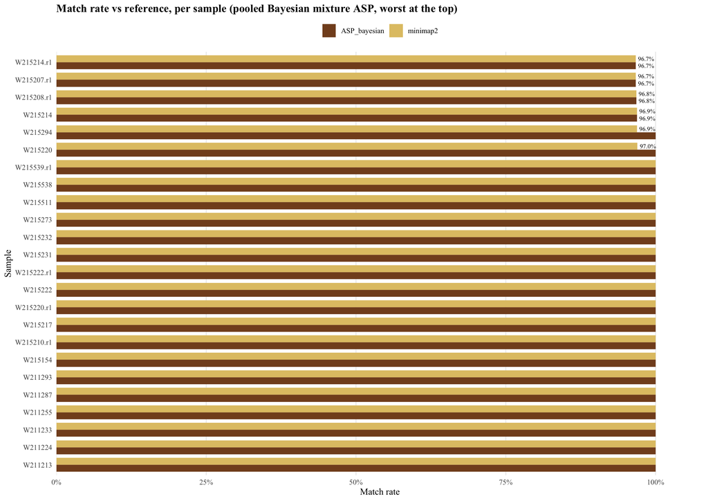

```r
# 2. Plot: Genotype match rate per sample
bayes_per_sample <- bayes_wide %>%
  filter(!is.na(reference)) %>%
  group_by(sample) %>%
  summarise(
    ASP_bayesian = mean(asp_match, na.rm = TRUE),
    minimap2 = mean(mm2_match, na.rm = TRUE)) %>%
  pivot_longer(cols = c(ASP_bayesian, minimap2), names_to = "method", values_to = "match_rate")

p_bayes_per_sample <- ggplot(bayes_per_sample, aes(x = match_rate, y = reorder(sample, -match_rate), fill = method)) +
  geom_col(position = position_dodge(width = 0.8), width = 0.8) +
  geom_text(aes(label = ifelse(match_rate < 1, percent(match_rate, accuracy = 0.1), "")),
            position = position_dodge(width = 0.8), hjust = -0.15, size = 2.6) +
  scale_fill_manual(values = method_colours, name = NULL) +
  scale_x_continuous(labels = percent, expand = expansion(mult = c(0, 0.08))) +
  labs(title = "Match rate vs reference, per sample (pooled Bayesian mixture ASP, worst at the top)", x = "Match rate", y = "Sample") +
  theme_minimal(base_family = plot_font, base_size = 11) +
  theme(plot.title = element_text(face = "bold"), legend.position = "top",
        panel.grid.major.y = element_blank(), panel.grid.minor = element_blank())

ggsave(file.path(bayes_out_dir, "concordance_per_sample_bayesian_mixpooled.png"), p_bayes_per_sample, width = 8.27, height = 11.69, dpi = 300, bg = "white")
ggsave(file.path(bayes_out_dir, "concordance_per_sample_bayesian_mixpooled.pdf"), p_bayes_per_sample, width = 8.27, height = 11.69, device = cairo_pdf)
print(p_bayes_per_sample)
```

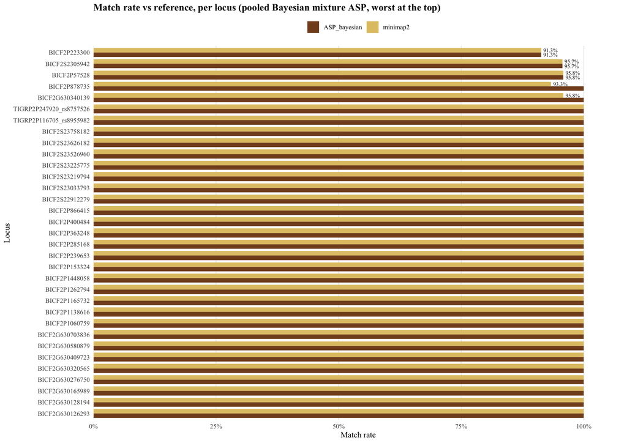

```r
# 3. Plot: Result concordance per locus
bayes_per_locus <- bayes_wide %>%
  filter(!is.na(reference)) %>%
  group_by(locus) %>%
  summarise(
    ASP_bayesian = mean(asp_match, na.rm = TRUE),
    minimap2 = mean(mm2_match, na.rm = TRUE)) %>%
  pivot_longer(cols = c(ASP_bayesian, minimap2), names_to = "method", values_to = "match_rate")

bayes_locus_avg <- bayes_per_locus %>% # average of both methods per locus, worst first
  group_by(locus) %>%
  summarise(avg_match = mean(match_rate, na.rm = TRUE)) %>%
  arrange(avg_match)

p_bayes_per_locus <- ggplot(bayes_per_locus, aes(x = match_rate, y = reorder(locus, -match_rate), fill = method)) +
  geom_col(position = position_dodge(width = 0.8), width = 0.8) +
  geom_text(aes(label = ifelse(match_rate < 1, percent(match_rate, accuracy = 0.1), "")),
            position = position_dodge(width = 0.8), hjust = -0.15, size = 2.6) +
  scale_fill_manual(values = method_colours, name = NULL) +
  scale_x_continuous(labels = percent, expand = expansion(mult = c(0, 0.08))) +
  labs(title = "Match rate vs reference, per locus (pooled Bayesian mixture ASP, worst at the top)", x = "Match rate", y = "Locus") +
  theme_minimal(base_family = plot_font, base_size = 11) +
  theme(plot.title = element_text(face = "bold"), legend.position = "top",
        panel.grid.major.y = element_blank(), panel.grid.minor = element_blank())

ggsave(file.path(bayes_out_dir, "concordance_per_locus_bayesian_mixpooled.png"), p_bayes_per_locus, width = 8.27, height = 11.69, dpi = 300, bg = "white")
ggsave(file.path(bayes_out_dir, "concordance_per_locus_bayesian_mixpooled.pdf"), p_bayes_per_locus, width = 8.27, height = 11.69, device = cairo_pdf)
print(p_bayes_per_locus)
```

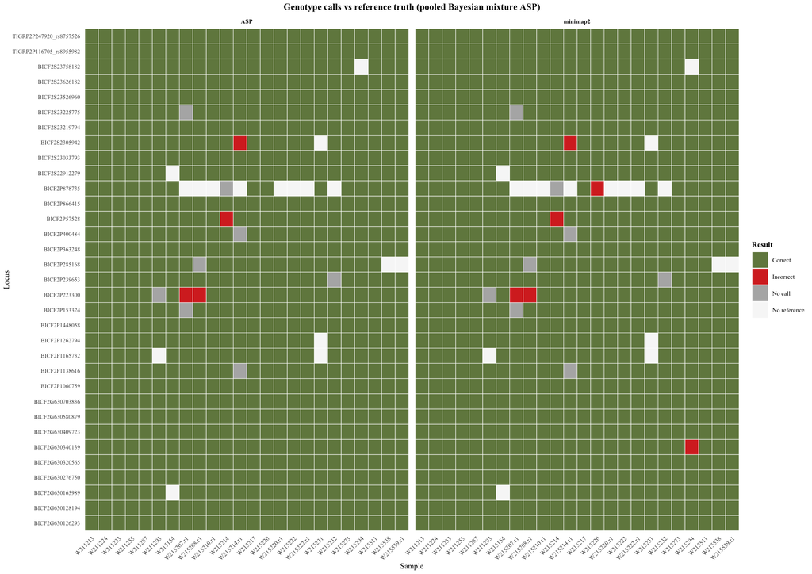

```r
# 4. Plot: Same as first heatmap just simpler with only red and green values for correct and incorrect called genotypes
bayes_match_data <- bayes_wide %>%
  select(sample, locus, reference, ASP = asp_match, minimap2 = mm2_match) %>%
  pivot_longer(cols = c(ASP, minimap2), names_to = "method", values_to = "is_match") %>%
  mutate(
    match_category = case_when(
      is.na(reference) ~ "No reference",
      is.na(is_match) ~ "No call",
      is_match ~ "Correct",
      TRUE ~ "Incorrect"))

p_bayes_match <- ggplot(bayes_match_data, aes(x = sample, y = locus, fill = match_category)) +
  geom_tile(colour = "white", linewidth = 0.2) +
  facet_wrap(~method, ncol = 2) +
  scale_fill_manual(
    values = c("Correct" = correct_colour, "Incorrect" = error_colour, "No call" = no_call_colour, "No reference" = no_reference_colour),
    name = "Result") +
  labs(title = "Genotype calls vs reference truth (pooled Bayesian mixture ASP)", x = "Sample", y = "Locus") +
  theme_minimal(base_family = plot_font, base_size = 8) +
  theme(plot.title = element_text(face = "bold", hjust = 0.5),
        legend.title = element_text(face = "bold"),
        strip.text = element_text(face = "bold"),
        axis.text.x = element_text(angle = 45, hjust = 1),
        axis.text.y = element_text(size = 6),
        panel.grid = element_blank())

ggsave(file.path(bayes_out_dir, "genotype_match_heatmap_bayesian_mixpooled.png"), p_bayes_match,
       width = max(9, length(unique(bayes_match_data$sample)) * 0.5 + 3),
       height = max(6, length(unique(bayes_match_data$locus)) * 0.15 + 2), dpi = 300, limitsize = FALSE, bg = "white")
ggsave(file.path(bayes_out_dir, "genotype_match_heatmap_bayesian_mixpooled.pdf"), p_bayes_match,
       width = max(9, length(unique(bayes_match_data$sample)) * 0.5 + 3),
       height = max(6, length(unique(bayes_match_data$locus)) * 0.15 + 2), limitsize = FALSE, device = cairo_pdf)
print(p_bayes_match)
```

## 4 HWE Ternary Plots for ASP and Bayes Genotypes

```r
# Uses data frames which were prepared in the setup chunk
hwe_ternary_dir <- file.path(graphics_dir, "HWE_Ternary_plots")
dir.create(hwe_ternary_dir, recursive = TRUE, showWarnings = FALSE)

# Skips loci with too few called samples (safety check with smaller datasets)
min_samples_per_locus <- 4
hwe_methods <- c("reference", "ASP", "ASP_bayesian")

# Deviation from HWE was tested with the exact test (Wigginton et al., 2005), p value is the sum of all outcomes that are as likely or less likely than the observed one. This function takes a number of HT majors and minors and number of HT for one specific locus across all samples and it checks wether these countswould look like randommating (is in HW equilibrium) or not (other factors).
hwe_exact_p <- function(n_hom_major, n_het, n_hom_minor) {
  n <- n_hom_major + n_het + n_hom_minor # Calculates number of samples
  n_minor <- 2 * min(n_hom_major, n_hom_minor) + n_het # Calculates number of minor alleles
  het_possible <- seq(n_minor %% 2, n_minor, by = 2) # Exact test asks keeps the minor alleles and asks in how many different ways could they split into genotypes
  log_prob <- vapply(het_possible, function(het) { # Vapply takes each possible HT split and applies it to the function. This gives the probability of getting each split if alleles were mixed randomly (HWE)
    hom_minor <- (n_minor - het) / 2 # Calculates other HM minor and major based on the number of HT split
    hom_major <- n - het - hom_minor
    # Probability calculations turned into log for ease of. use with "+" and "-" ("P(counts|allele counts) = n!/(n_AA!*n_AB!*n_BB!)*2^n_AB*n_A!*n_B!/(2n)!")
    lfactorial(n) - lfactorial(hom_major) - lfactorial(het) - lfactorial(hom_minor) + het * log(2) +
      lfactorial(n_minor) + lfactorial(2 * n - n_minor) - lfactorial(2 * n)
  }, numeric(1))
  prob <- exp(log_prob) # Turned back to normal probability
  observed_prob <- prob[het_possible == n_het] # Takes the probability of that split if the popualtion were in HWE
  min(1, sum(prob[prob <= observed_prob * (1 + 1e-7)])) # p-value is the sum of all splits probabilites which are even less likely or as likely
}

# All called genotypes fo the three methods, filtered for loci with enough samples
hwe_calls <- bind_rows(ref, asp, select(bayes_asp, -status)) %>%
  filter(!is.na(genotype)) %>%
  group_by(method, locus) %>%
  filter(n() >= min_samples_per_locus) %>%
  ungroup()

# Counts allele copies per method and locus
hwe_allele_counts <- hwe_calls %>%
  mutate(allele_1 = substr(genotype, 1, 1), allele_2 = substr(genotype, 2, 2)) %>%
  pivot_longer(c(allele_1, allele_2), values_to = "allele") %>%
  count(method, locus, allele)

# Loci with moren than 2 different alleles are erros, they are left out in further analysis
hwe_too_many_alleles <- hwe_allele_counts %>% count(method, locus, name = "n_alleles") %>% filter(n_alleles > 2)
if (nrow(hwe_too_many_alleles) > 0) print(hwe_too_many_alleles)

# Major and minor alleles per method and locus
hwe_alleles <- hwe_allele_counts %>%
  group_by(method, locus) %>%
  filter(n() == 2) %>%
  arrange(desc(n), allele, .by_group = TRUE) %>%
  summarise(major = allele[1], minor = allele[2], .groups = "drop")

#Genotype counts per method and locus and applied exact test with HWE statistics
hwe_counts <- hwe_calls %>%
  inner_join(hwe_alleles, by = c("method", "locus")) %>%
  group_by(method, locus) %>%
  summarise(n = n(),
            n_hom_major = sum(genotype == paste0(major, major)),
            n_het = sum(genotype %in% c(paste0(major, minor), paste0(minor, major))),
            n_hom_minor = sum(genotype == paste0(minor, minor)),
            .groups = "drop") %>%
  group_by(locus) %>%
  filter(n_distinct(method) == length(hwe_methods)) %>% # Filter for same loci across methods so its comparable
  ungroup() %>%
  mutate(major_freq = (2 * n_hom_major + n_het) / (2 * n),
         he = 2 * major_freq * (1 - major_freq), # HWE expected HT
         ho = n_het / n, # HT observed
         f = 1 - ho / he, # Inbreeding coeeficient, if its > 0 to few HT, < 0 too many HT
         hwe_p = mapply(hwe_exact_p, n_hom_major, n_het, n_hom_minor), # Applies previously defined exact test function
         hwe_result = case_when(hwe_p >= 0.05 ~ "In HWE",
                                ho < he ~ "Heterozygote deficit (p < 0.05)",
                                TRUE ~ "Heterozygote excess (p < 0.05)"),
         method = factor(method, levels = hwe_methods))

# 1. Plot: Genotype posterior ternary plot for Bayes only
ternary_called <- filter(bayes_raw, status == "called")
ternary_confidence <- cut(ternary_called$max_posterior, breaks = c(-Inf, 0.80, 0.95, Inf), right = FALSE,
                          labels = c("uncertain (<0.80)", "intermediate (0.80-0.95)", "high (>=0.95)"))
ternary_colours <- c("uncertain (<0.80)" = error_colour, "intermediate (0.80-0.95)" = "#D9B44A", "high (>=0.95)" = correct_colour)

# Calcualates positions for each locus in the triangle (HT at the top, HM1 at x = 0 y = 0, and HM2 at x = 1, y = 0)
tern_x <- function(ab, bb) bb + ab / 2 # MAF
tern_y <- function(ab) ab * sqrt(3) / 2

# Grid lines at 25, 50 and 75 % of each genotype
ternary_shares <- c(0.25, 0.5, 0.75)
ternary_grid <- bind_rows(
  tibble(x = tern_x(ternary_shares, 0), y = tern_y(ternary_shares), xend = tern_x(ternary_shares, 1 - ternary_shares), yend = tern_y(ternary_shares)), # HT share
  tibble(x = tern_x(0, ternary_shares), y = 0, xend = tern_x(1 - ternary_shares, ternary_shares), yend = tern_y(1 - ternary_shares)), # HM2 share
  tibble(x = tern_x(0, 1 - ternary_shares), y = 0, xend = tern_x(1 - ternary_shares, 0), yend = tern_y(1 - ternary_shares))) # HM1 share

p_ternary_posterior <- ggplot(mutate(ternary_called, confidence = ternary_confidence),
                              aes(x = tern_x(posterior_het, posterior_hom2), y = tern_y(posterior_het), colour = confidence)) +
  geom_segment(data = ternary_grid, aes(x = x, y = y, xend = xend, yend = yend), colour = "grey90", inherit.aes = FALSE) +
  annotate("polygon", x = c(0, 1, 0.5), y = c(0, 0, sqrt(3) / 2), fill = NA, colour = "grey60") +
  annotate("text", x = c(0, 1, 0.5), y = c(-0.04, -0.04, sqrt(3) / 2 + 0.04), label = c("hom1", "hom2", "het")) +
  geom_point(size = 1.6) +
  scale_colour_manual(values = ternary_colours, breaks = rev(names(ternary_colours)), name = NULL) +
  coord_equal(xlim = c(-0.08, 1.08), ylim = c(-0.08, 0.95), expand = FALSE) +
  labs(title = sprintf("Genotype posterior ternary plot - hierarchical base mixture (n=%d)", nrow(ternary_called))) +
  theme_void(base_family = plot_font, base_size = 11) +
  theme(plot.title = element_text(hjust = 0.5, size = 10, face = "bold"), legend.position = "bottom",
        plot.background = element_rect(fill = "white", colour = NA))
```

```r
#print(p_ternary_posterior)
#ggsave(file.path(hwe_ternary_dir, "ternary_posterior_bayesian.png"), p_ternary_posterior, width = 7, height = 6.5, dpi = 300, bg = "white")
#ggsave(file.path(hwe_ternary_dir, "ternary_posterior_bayesian.pdf"), p_ternary_posterior, width = 7, height = 6.5, device = cairo_pdf)

# 2. Plot: HWE ternary plot by locus, each observed locus moves away from its reference genotypes, the difference is presented with arrows. MAF is along the base, AA is awlays the major one, so only half the traingle is needed

tern_n <- median(hwe_counts$n) # typical number of called samples per locus
tern_n_loci <- n_distinct(hwe_counts$locus)

#small tibble for each curve described by F (inbreeding coeficcient)
tern_edges <- tibble(edge = c("hwe", "nominal_low", "nominal_high", "bonferroni_low", "bonferroni_high"), # chi-square HWE test accepts |F| below the limit
                     f = c(0, 1, -1, 1, -1) * sqrt(qchisq(1 - 0.05 / c(1, 1, 1, tern_n_loci, tern_n_loci), df = 1) / tern_n))

tern_curves <- expand_grid(p = seq(0.5, 1, by = 0.001), tern_edges) %>%
  mutate(ab = 2 * p * (1 - p) * (1 - f),
         aa = p - ab / 2,
         bb = 1 - p - ab / 2) %>%
  filter(aa >= 0, bb >= 0) %>%
  mutate(x = tern_x(ab, bb), y = tern_y(ab))
tern_band <- bind_rows(filter(tern_curves, edge == "nominal_high") %>% arrange(p), # 95 % band polygon
                       filter(tern_curves, edge == "nominal_low") %>% arrange(desc(p)))

# Left half of the triangle
tern_half <- tibble(x = c(0, 0.5, 0.5), y = c(0, 0, sqrt(3) / 2))

# Lines for equal HT share
tern_het_lines <- tibble(het = c(0.25, 0.5, 0.75)) %>%
  mutate(x = het / 2, y = tern_y(het))
tern_maf_ticks <- tibble(x = seq(0, 0.5, by = 0.1))


tern_curve_labels <- tern_edges %>%
  filter(edge %in% c("hwe", "nominal_high", "bonferroni_high")) %>%
  mutate(x = 0.46, # MAF where the arrows point, just inside the right side
         y = tern_y(2 * 0.54 * 0.46 * (1 - f)),
         label = c("Hardy-Weinberg\nequilibrium",
                   sprintf("95%% acceptance band\n(chi-square, %d samples)", tern_n),
                   sprintf("Bonferroni band\n(%d loci)", tern_n_loci)),
         label_y = y + c(0.08, 0.02, 0.06)) # labels sit a little above their curve

hw_ternary_plot <- function(method_name, display_name) { # short names used in title and legend
  tern_points <- hwe_counts %>%
    filter(method %in% c("reference", method_name)) %>%
    mutate(x = tern_x(n_het / n, n_hom_minor / n), y = tern_y(n_het / n))

  # one row per locus for reference and called position
  tern_moves <- tern_points %>%
    transmute(locus, source = ifelse(method == "reference", "ref", "called"), x, y) %>%
    pivot_wider(names_from = source, values_from = c(x, y)) %>%
    mutate(length = sqrt((x_called - x_ref)^2 + (y_called - y_ref)^2),
           gap = 0.01 / length) %>% # small gap for arrows
    filter(length > 0.025) %>%
    mutate(x_start = x_ref + (x_called - x_ref) * gap, y_start = y_ref + (y_called - y_ref) * gap,
           x_end = x_called - (x_called - x_ref) * gap, y_end = y_called - (y_called - y_ref) * gap)

  tern_failed <- sum(tern_points$method == method_name & tern_points$hwe_result != "In HWE")

  tern_labels <- c("In HWE" = sprintf("%s genotypes in HWE", display_name),
                   "Heterozygote deficit (p < 0.05)" = sprintf("%s genotypes, HT deficit (p < 0.05)", display_name),
                   "Heterozygote excess (p < 0.05)" = sprintf("%s genotypes, HT excess (p < 0.05)", display_name))

  tern_plot <- ggplot() +
    geom_polygon(data = tern_band, aes(x = x, y = y), fill = "grey90") +
    geom_path(data = filter(tern_curves, startsWith(edge, "bonferroni")), aes(x = x, y = y, group = edge), linetype = "dotted", colour = "grey50") +
    geom_segment(data = tern_het_lines, aes(x = x, xend = 0.5, y = y, yend = y), colour = "grey85", linewidth = 0.3) +
    geom_text(data = tern_het_lines, aes(x = 0.51, y = y, label = sprintf("%.0f%% het", het * 100)), hjust = 0, size = 2.8, colour = "grey55") +
    geom_polygon(data = tern_half, aes(x = x, y = y), fill = NA, colour = "grey40", linewidth = 0.5) +
    geom_path(data = filter(tern_curves, edge == "hwe"), aes(x = x, y = y), linetype = "dashed", colour = "grey25") +
    geom_segment(data = tern_curve_labels, aes(x = 0.575, y = label_y, xend = x, yend = y), colour = "grey40", linewidth = 0.3,
                 arrow = arrow(length = unit(1.3, "mm"), type = "closed")) +
    geom_text(data = tern_curve_labels, aes(x = 0.58, y = label_y, label = label), hjust = 0, size = 2.9, colour = "grey25", lineheight = 0.95) +
    geom_segment(data = tern_moves, aes(x = x_start, y = y_start, xend = x_end, yend = y_end, linetype = "shift"), colour = "grey55", linewidth = 0.4,
                 arrow = arrow(length = unit(1.6, "mm"), type = "closed"), key_glyph = "path") +
    geom_point(data = filter(tern_points, method == "reference"), aes(x = x, y = y, shape = "reference"), fill = "white", colour = "grey35", size = 2.2) +
    geom_point(data = filter(tern_points, method == method_name), aes(x = x, y = y, colour = hwe_result), size = 2.4, alpha = 0.85) +
    annotate("text", x = 0, y = 0.82, hjust = 0, vjust = 1, size = 4.6, fontface = "bold", lineheight = 1.1, colour = "grey15",
             label = sprintf("Genotype frequencies per locus\nvs Hardy-Weinberg\nreference -> %s", display_name)) +
    annotate("text", x = 0, y = 0.70, hjust = 0, vjust = 1, size = 3.1, fontface = "bold", lineheight = 1.2, colour = "grey15",
             label = sprintf("%d of %d loci fail the exact HWE test\n(%.1f expected by chance).", tern_failed, tern_n_loci, 0.05 * tern_n_loci)) +
    annotate("text", x = 0, y = 0.63, hjust = 0, vjust = 1, size = 3.1, lineheight = 1.2, colour = "grey15",
             label = "Each point is one locus, placed by\nthe share of its samples called\nAA (major homozygote),\nAB (heterozygote) and\nBB (minor homozygote).\n\nBelow the band =\ntoo few heterozygotes.") +
    geom_segment(data = tern_maf_ticks, aes(x = x, xend = x, y = 0, yend = -0.012), colour = "grey40") + # MAF axis
    geom_text(data = tern_maf_ticks, aes(x = x, y = -0.035, label = x), size = 3, colour = "grey30") +
    annotate("text", x = 0.25, y = -0.08, label = "Minor allele frequency", size = 3.5) +
    annotate("text", x = -0.015, y = 0, label = "AA", hjust = 1, size = 4, fontface = "bold") +
    annotate("text", x = 0.5, y = sqrt(3) / 2 + 0.03, label = "AB", size = 4, fontface = "bold") +
    scale_colour_manual(values = c("In HWE" = "grey30", "Heterozygote deficit (p < 0.05)" = hm_dark, "Heterozygote excess (p < 0.05)" = ht_dark),
                        labels = tern_labels, name = NULL) +
    scale_shape_manual(values = c(reference = 21), labels = c(reference = "Reference"), name = NULL) +
    scale_linetype_manual(values = c(shift = "solid"), labels = c(shift = "Shift from reference"), name = NULL) +
    guides(shape = guide_legend(order = 1), linetype = guide_legend(order = 2), colour = guide_legend(order = 3, nrow = 1)) +
    coord_equal(xlim = c(-0.1, 0.75), ylim = c(-0.09, 0.9), expand = FALSE, clip = "off") +
    theme_void(base_family = plot_font, base_size = 11) +
    theme(legend.position = "bottom", legend.box = "horizontal", legend.spacing.x = unit(12, "pt"),
          plot.margin = margin(10, 20, 10, 20))
```

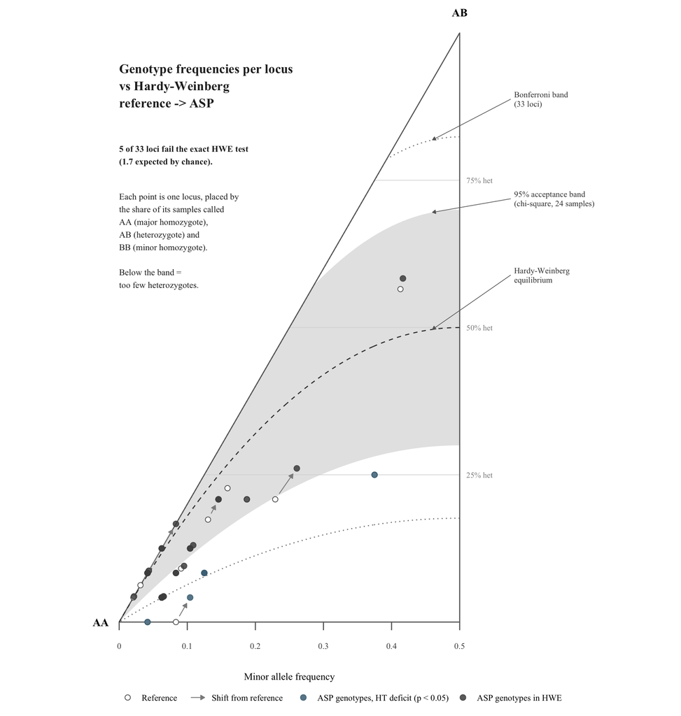

```r
  ggsave(file.path(hwe_ternary_dir, sprintf("hw_ternary_by_locus_%s.png", method_name)), tern_plot, width = 9.5, height = 10, dpi = 300, bg = "white")
  ggsave(file.path(hwe_ternary_dir, sprintf("hw_ternary_by_locus_%s.pdf", method_name)), tern_plot, width = 9.5, height = 10, device = cairo_pdf)
  tern_plot
}

p_tern_asp <- hw_ternary_plot("ASP", "ASP")
p_tern_bayesian <- hw_ternary_plot("ASP_bayesian", "Bayes")
print(p_tern_asp)
```

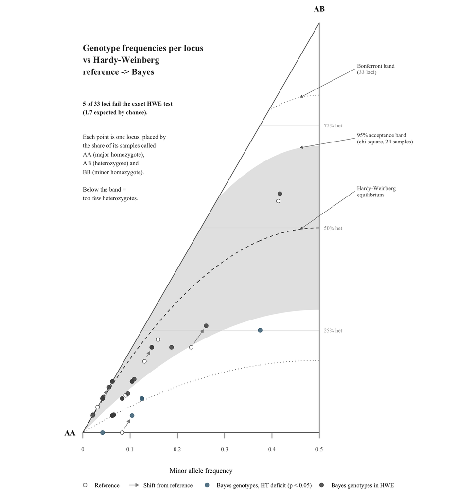

```r
print(p_tern_bayesian)
```

## 5 Depth and HM/HT heatmap

This chunk holds a function for two types of heatmaps, one for depth and one for zygosity. It calls it for both Bayes and ASP genotyper and saves plots automatically into seperate folders. Heatmaps shows all the called genotypes by HM and HT pairs, call with no reference (black outline), wrongly called genotypes (black crosses) and no calls caused by low depth. Note: low depth is set in the master pipeline, for plots created at the moment its set way too low at minimum depth of 3. This should be changed for final results, which would in turn also bring the accuracy of the genotyper closer to 100 %.

```r
make_genotype_plot <- function(asp_df, method_label, ref, out_path, plot_title, type = c("zygosity", "depth"), panel_title = method_label) {
  type <- match.arg(type)
# Read totals order from top to bottom (highest to lowest depth locus) and left to right (highest to lowest depth sample), data preparation
  locus_totals <- asp_df %>%
    group_by(locus) %>%
    summarise(total_reads = sum(depth, na.rm = TRUE)) %>%
    arrange(desc(total_reads))

  sample_totals <- asp_df %>%
    group_by(sample) %>%
    summarise(total_reads = sum(depth, na.rm = TRUE)) %>%
    arrange(desc(total_reads))

  sample_order <- sample_totals$sample
  locus_levels <- rev(locus_totals$locus)

# one row per sample locus pair, calls without a reference keep the value but they are marked with a black outline as no reference calls, pairs which did not produce a call are grey
  method_tiles <- asp_df %>%
    left_join(select(ref, sample, locus, reference = genotype), by = c("sample", "locus"), relationship = "one-to-one") %>%
    mutate(zygosity = case_when(is.na(reference) & is.na(genotype) ~ "No reference",
                                is.na(genotype) ~ "No call",
                                substr(genotype, 1, 1) == substr(genotype, 2, 2) ~ "Homozygous",
                                TRUE ~ "Heterozygous"),
           zygosity = factor(zygosity, levels = c("Homozygous", "Heterozygous", "No call", "No reference")),
           no_reference_call = is.na(reference) & !is.na(genotype),
           locus = factor(locus, levels = locus_levels),
           sample = factor(sample, levels = sample_order))

  no_reference_cells <- filter(method_tiles, no_reference_call) # calls with no reference
  scored_tiles <- filter(method_tiles, !is.na(reference), !is.na(genotype)) # calls with reference

# Plot subtitle preparation, show number of called pairs, number of misscalled pairs and accuracy
  miscall_subtitle <- scored_tiles %>%
    mutate(reference_zygosity = ifelse(substr(reference, 1, 1) == substr(reference, 2, 2), "homozygous", "heterozygous")) %>%
    count(reference_zygosity, miscalled = genotype != reference) %>%
    filter(miscalled) %>%
    mutate(label = sprintf("%d miscalled %s genotype%s", n, reference_zygosity, ifelse(n == 1, "", "s"))) %>%
    pull(label) %>%
    paste(collapse = ", ")

  if (miscall_subtitle == "") miscall_subtitle <- "no miscalled genotypes"
  n_called_with_ref <- nrow(scored_tiles)
  n_correct <- sum(scored_tiles$genotype == scored_tiles$reference)
  accuracy_subtitle <- if (n_called_with_ref == 0) {sprintf("no %s/reference overlap to score", method_label)} else {
    sprintf("%d/%d calls correct (%.1f%% accuracy)", n_correct, n_called_with_ref, 100 * n_correct / n_called_with_ref)
  }

# Call rate over all sample locus pairs, including those without a reference
  n_pairs_total <- length(sample_order) * length(locus_levels)
  n_called_total <- sum(!is.na(method_tiles$genotype))
  call_rate_subtitle <- sprintf("Call rate: %d/%d (%.1f%%)", n_called_total, n_pairs_total, 100 * n_called_total / n_pairs_total)

# Saves pairs with wrong calls
  mismatch_cells <- filter(scored_tiles, genotype != reference)

  heatmap_theme <- theme_minimal(base_family = plot_font, base_size = 8) +
    theme(axis.text.x = element_text(angle = 45, hjust = 1), axis.text.y = element_text(size = 7.5),
          panel.grid = element_blank(), plot.margin = margin(t = -10, r = 2, b = 4, l = 4),
          legend.title = element_text(face = "bold"),
          legend.key.size = unit(14, "pt"),
          legend.key.spacing.y = unit(4, "pt"),
          legend.spacing.y = unit(4, "pt"),
          legend.margin = margin(0, 0, 0, 0))

# black outlines for calls with no reference are drawn a little bit inside the tile so it doesnt touch other cells
no_reference_outline <- geom_tile(data = no_reference_cells, aes(x = sample, y = locus), fill = NA, colour = "black",
                                  linewidth = 0.5, width = 0.9, height = 0.9, inherit.aes = FALSE)

# Because the extra markers are not mapped in aes() they need an extra step for legend. Custom legend entries for the two extra markers, creates marker labels and marker key which creates two entries for legend (shape is mapped to marker with alpha = 0 which makes it transparent)
  marker_labels <- c(sprintf("Called, no reference (%d)", nrow(no_reference_cells)),
                     sprintf("Incorrect call (%d)", nrow(mismatch_cells)))

# Two placeholder rows (one per legend entry) on an existing tile used to create a legend
  marker_key <- data.frame(sample = factor(sample_order[1], levels = sample_order),
                           locus = factor(locus_levels[length(locus_levels)], levels = locus_levels),
                           marker = factor(marker_labels, levels = marker_labels))

# This makes the two figures for two legend entries, one box split diagonally into both colours and one with black outline or X on top
  make_draw_key_marks <- function(fill_low, fill_high) {
    function(data, params, size) { # polygonGrob hold instructions for building a graphical object
      split_tile <- list(polygonGrob(x = c(0, 1, 0), y = c(0, 0, 1), gp = gpar(fill = fill_low, col = NA)), # two triangles for legend
                         polygonGrob(x = c(1, 1, 0), y = c(0, 1, 1), gp = gpar(fill = fill_high, col = NA)))
      mark <- if (data$shape == 0) { # rectGrob makes a rectangle
        rectGrob(width = 1, height = 1, gp = gpar(fill = NA, col = "black", lwd = 1.3)) # gpar set the look of graphical objects - black outline
      } else { # pointsGrob makes points symbols
        pointsGrob(0.5, 0.5, pch = 4, gp = gpar(col = "black", lwd = 2, cex = 0.9)) # X marker on the heatmap
      }
      do.call(grobTree, c(split_tile, list(mark))) # This groups several "grobs" (graphical objects) together, one on top of the other
    }
  }

# geom_point() plots those marker_key entries with shape mapped to marker
  make_marker_legend <- function(fill_low, fill_high) list(
    geom_point(data = marker_key, aes(x = sample, y = locus, shape = marker), alpha = 0, inherit.aes = FALSE, # transparent points
               key_glyph = make_draw_key_marks(fill_low, fill_high)),
    scale_shape_manual(values = setNames(c(0, 4), marker_labels), name = NULL), #
    guides(shape = guide_legend(override.aes = list(alpha = 1), order = 2, byrow = TRUE,
                                theme = theme(legend.title = element_blank()))))
```

```r
# Based on input type it creates a different plot, here the heatmaps actually differ
  if (type == "zygosity") {
    zygosity_fills <- c("Homozygous" = hm_dark, "Heterozygous" = ht_dark, "No call" = no_call_colour, "No reference" = no_reference_colour)

    # Legend labels with numbers of tiles showing results clearly
    zygosity_counts <- table(method_tiles$zygosity) # Counts all four factors of zygosity
    zygosity_labels <- setNames(sprintf("%s (%d)", names(zygosity_counts), as.integer(zygosity_counts)), names(zygosity_counts))

    # Heatmap for zygosity
    panels <- ggplot(method_tiles, aes(x = sample, y = locus, fill = zygosity)) +
      geom_tile(colour = "white", linewidth = 0.2) +
      no_reference_outline +
      geom_point(data = mismatch_cells, aes(x = sample, y = locus, colour = zygosity),
                 shape = 4, size = 2.5, stroke = 1.3, inherit.aes = FALSE, show.legend = FALSE) +
      scale_fill_manual(values = zygosity_fills, labels = zygosity_labels, name = "LEGEND", drop = FALSE) +
      scale_colour_manual(values = c("Homozygous" = "white", "Heterozygous" = "white"), guide = "none") +
      guides(fill = guide_legend(override.aes = list(colour = "grey50", linewidth = 0.3), order = 1, byrow = TRUE)) + # grey border for "No reference"
      make_marker_legend(zygosity_fills[["Homozygous"]], zygosity_fills[["Heterozygous"]]) +
      labs(title = panel_title, x = "Sample", y = "Locus") +
      heatmap_theme +
      theme(plot.title = element_text(hjust = 0.5, face = "bold"), plot.margin = margin(4, 4, 4, 4))

    combined_layout <- plot_layout(guides = "collect") # Legend on the right side, using patchwork for consistency with the depth heatmap
  } else {

# 2.Plot: Depth heatmap with sample depth on top and locus depth on the right side (ordered)
    # Only two axis marks so one in the middle and one for max value
    orientation_breaks <- function(totals) signif(c(max(totals) / 2, max(totals)), 2)
    reads_axis_labels <- label_number(scale = 1e-3, suffix = "k", accuracy = 1)

    # First panel for sample depth
    p_sample_reads <- ggplot(sample_totals %>%
                            mutate(sample = factor(sample, levels = sample_order)), aes(x = sample, y = total_reads)) +
      geom_col(fill = "grey50", width = 0.8) +
      scale_y_continuous(limits = c(0, NA), breaks = orientation_breaks(sample_totals$total_reads), labels = reads_axis_labels,
                         expand = expansion(mult = c(0, 0.08))) +
      theme_minimal(base_family = plot_font, base_size = 8) +
      theme(axis.text.x = element_blank(), axis.title.x = element_blank(),
            panel.grid.minor = element_blank(), panel.grid.major.x = element_blank(),
            plot.title = element_text(hjust = 0.5, face = "bold")) +
      labs(y = "Reads", title = panel_title)

    # Second panel for locus depth
    p_locus_reads <- ggplot(locus_totals %>%
                              mutate(locus = factor(locus, levels = locus_levels)), aes(x = total_reads, y = locus)) +
      geom_col(fill = "grey50", width = 0.8) +
      scale_x_continuous(limits = c(0, NA), breaks = orientation_breaks(locus_totals$total_reads), labels = reads_axis_labels,
                         expand = expansion(mult = c(0, 0.08))) +
      theme_minimal(base_family = plot_font, base_size = 8) +
      theme(axis.text.y = element_blank(), axis.title.y = element_blank(),
            panel.grid.minor = element_blank(), panel.grid.major.y = element_blank()) +
      labs(x = "Reads")

    # Main panel showing depth heatmap
    p_main <- ggplot(method_tiles, aes(x = sample, y = locus)) +
      geom_tile(data = filter(method_tiles, !is.na(genotype)), aes(fill = depth), colour = "white", linewidth = 0.2) +
      geom_tile(data = filter(method_tiles, zygosity == "No call"), fill = no_call_colour, colour = "white", linewidth = 0.2) +
      geom_tile(data = filter(method_tiles, zygosity == "No reference"), fill = no_reference_colour, colour = "white", linewidth = 0.2) +
      no_reference_outline +
      geom_point(data = mismatch_cells, aes(x = sample, y = locus), shape = 4, size = 2, stroke = 1.3, colour = "black", inherit.aes = FALSE) +
      make_marker_legend("#A4B591", "#A4B591") +
      scale_fill_gradient(low = "#F1E4DB", high = "#2C5724", transform = "log1p", name = "Depth (reads)", # log because it goes from 3 to 3000
                          breaks = c(3, 10, 30, 100, 300, 1000, 3000), labels = label_comma(),
                          guide = guide_colourbar(order = 1)) +
      labs(x = "Sample", y = "Locus") +
      heatmap_theme

    # Plot is split into 11 column, 9 for heatmap, 1 for locus reads  and one for legends and 10 rows 1 for sample reads and 9 for heatmap
    layout <- c(area(t = 1, l = 1, b = 1, r = 9),
                area(t = 2, l = 1, b = 10, r = 9),
                area(t = 2, l = 10, b = 10, r = 10),
                area(t = 2, l = 11, b = 10, r = 12))
    panels <- p_sample_reads + p_main + p_locus_reads + guide_area()
    combined_layout <- plot_layout(design = layout, guides = "collect")}

 # Combines the panels and layout and saves the plots
  p_combined <- panels +
    combined_layout +
    plot_annotation(title = plot_title, # Annotation and legend theme for the whole plot not separate panels
                            subtitle = sprintf("%s | %s vs reference: %s | %s", call_rate_subtitle, method_label, miscall_subtitle, accuracy_subtitle),
                            theme = theme(plot.title = element_text(hjust = 0.5, face = "bold"),
                                             plot.subtitle = element_text(hjust = 0.5),
                                             legend.spacing.y = unit(4, "pt"),
                                             legend.justification = c(0, 0.5),
                                             legend.box.margin = margin(0, 0, 0, -10)))

  # saving in landscape both plots
  ggsave(out_path, p_combined, width = 11.69, height = 8.27, dpi = 300, bg = "white")
  ggsave(sub("\\.png$", ".pdf", out_path), p_combined, width = 11.69, height = 8.27, device = cairo_pdf)
```

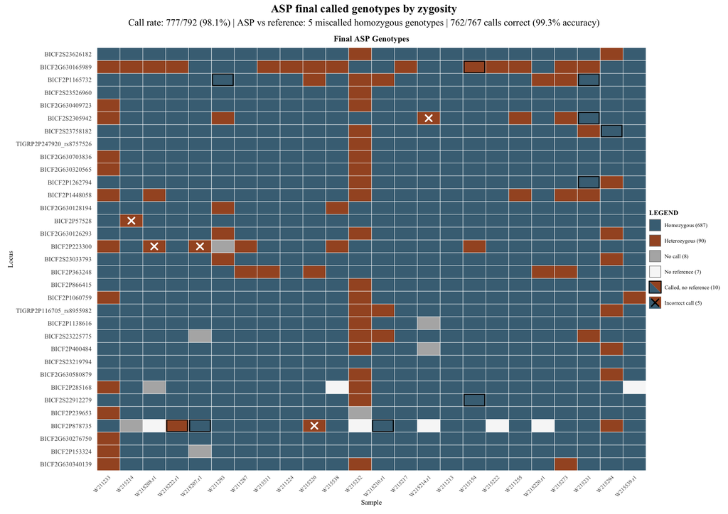

```r
  p_combined
}

### Function calling

identified_genotypes <- transmute(asp_results, sample = barcode, locus, genotype, depth) # ASP calls with their read depth
bayes_genotypes <- transmute(bayes_raw, sample = barcode, locus, genotype, depth) # Bayesian calls with their read depth
mm2_genotypes <- transmute(mm2_raw, sample = barcode, locus, genotype, depth) # Minimap 2 calls with their read depth

identified_zygosity_plot <- make_genotype_plot(identified_genotypes, "ASP", ref,
                                               out_path = file.path(out_dir, "genotype_zygosity_heatmap.png"),
                                               plot_title = "ASP final called genotypes by zygosity",
                                               type = "zygosity", panel_title = "Final ASP Genotypes")

identified_depth_plot <- make_genotype_plot(identified_genotypes, "ASP", ref,
                                            out_path = file.path(out_dir, "genotype_depth_heatmap.png"),
                                            plot_title = "ASP final called genotypes by read depth",
                                            type = "depth", panel_title = "Final ASP Genotypes")

bayes_zygosity_plot <- make_genotype_plot(bayes_genotypes, "Bayesian ASP", ref,
                                          out_path = file.path(bayes_out_dir, "genotype_zygosity_heatmap_bayesian.png"),
                                          plot_title = "Bayesian ASP final called genotypes by zygosity",
                                          type = "zygosity", panel_title = "Final Bayesian ASP Genotypes")

bayes_depth_plot <- make_genotype_plot(bayes_genotypes, "Bayesian ASP", ref,
                                       out_path = file.path(bayes_out_dir, "genotype_depth_heatmap_bayesian.png"),
                                       plot_title = "Bayesian ASP final called genotypes by read depth",
                                       type = "depth", panel_title = "Final Bayesian ASP Genotypes")

mm2_zygosity_plot <- make_genotype_plot(mm2_genotypes, "Minimap2", ref,
                                        out_path = file.path(mm2_out_dir, "genotype_zygosity_heatmap_minimap2.png"),
                                        plot_title = "Minimap2 final called genotypes by zygosity",
                                        type = "zygosity", panel_title = "Final Minimap2 Genotypes")

mm2_depth_plot <- make_genotype_plot(mm2_genotypes, "Minimap2", ref,
                                     out_path = file.path(mm2_out_dir, "genotype_depth_heatmap_minimap2.png"),
                                     plot_title = "Minimap2 final called genotypes by read depth",
                                     type = "depth", panel_title = "Final Minimap2 Genotypes")

print(identified_zygosity_plot)
```

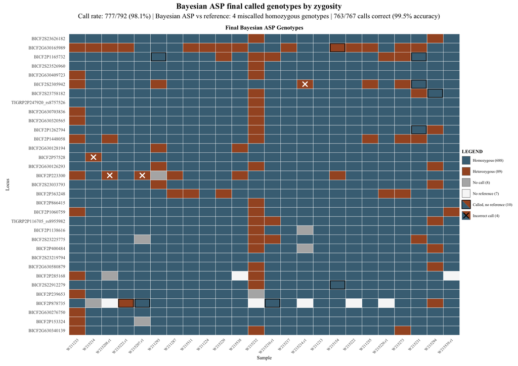

```r
print(bayes_zygosity_plot)
```

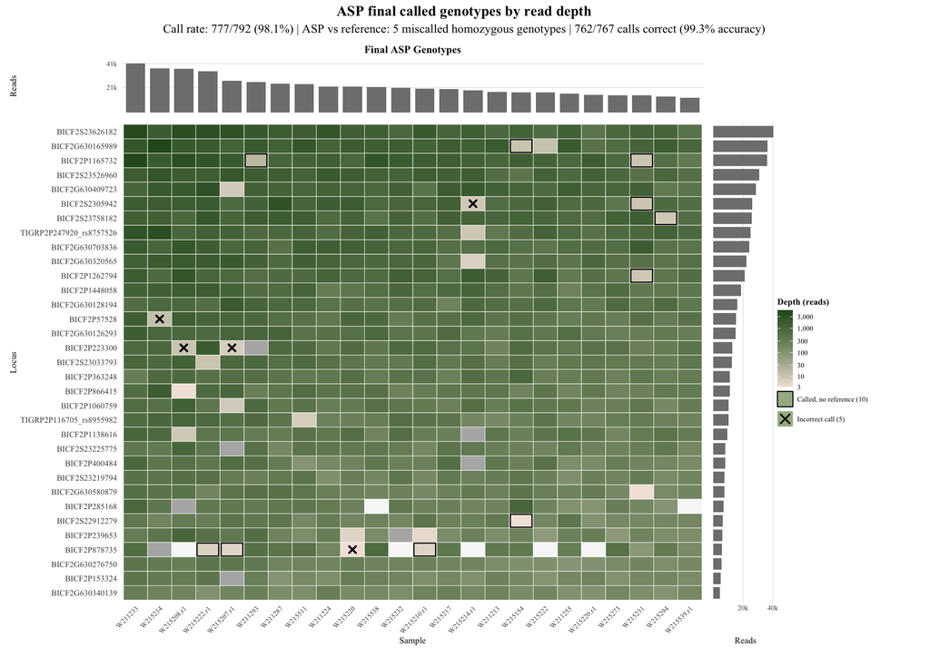

```r
print(identified_depth_plot)
```

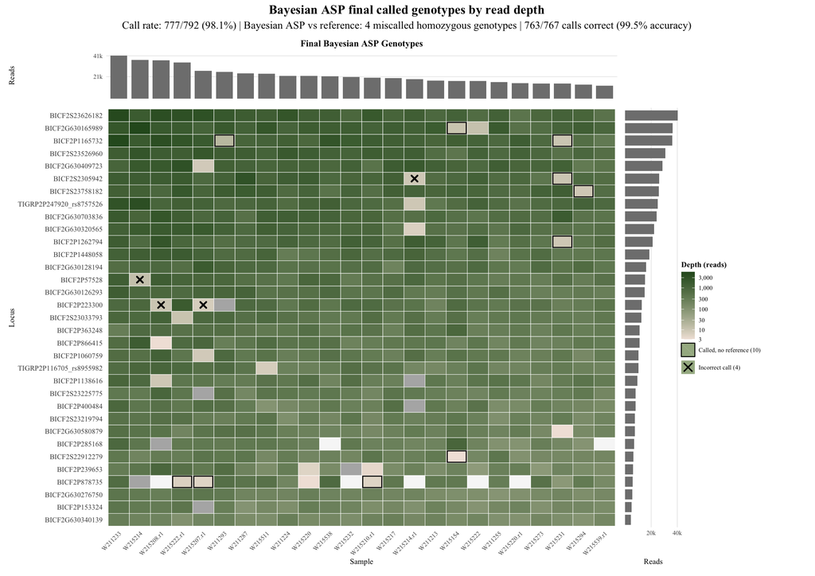

```r
print(bayes_depth_plot)
```

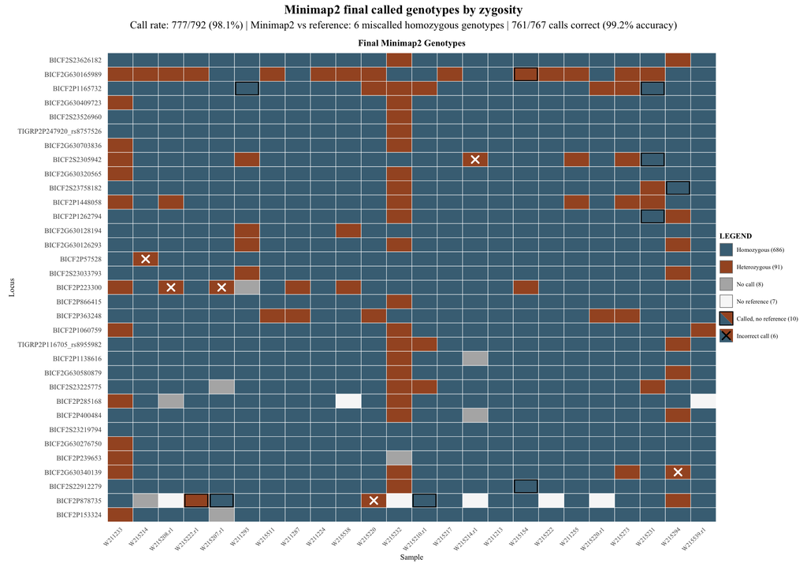

```r
print(mm2_zygosity_plot)
```

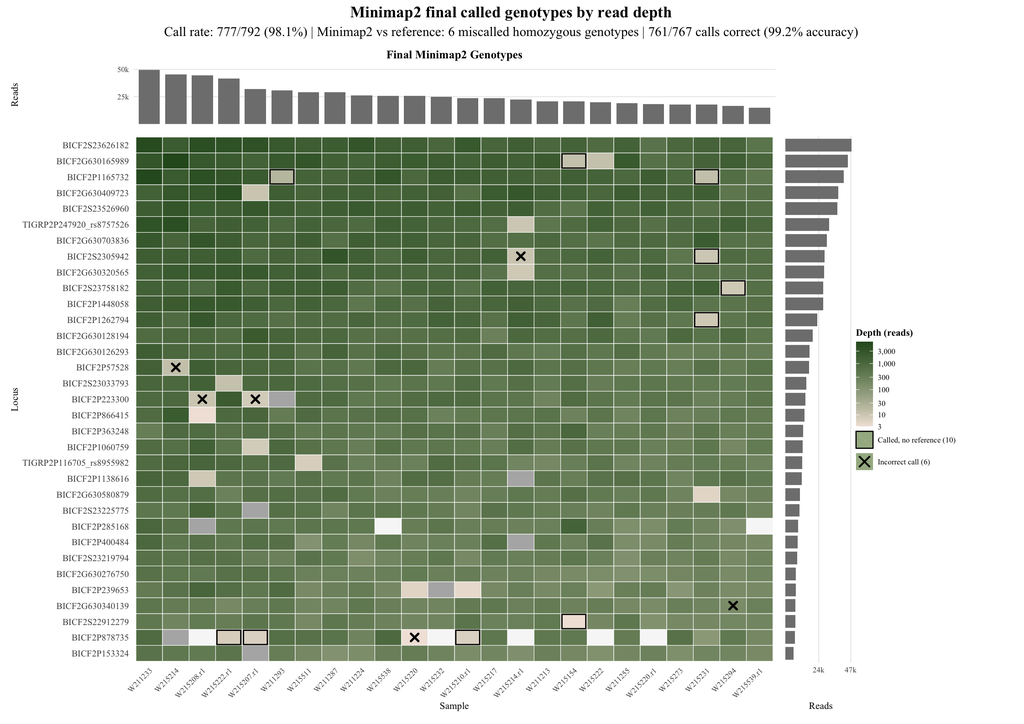

```r
print(mm2_depth_plot)
```